# 1000plus collateral flow & perfusion project

Ahmed Khalil

23 November, 2018

### General remarks on methods:

**Reperfusion** is defined as a relative Tmax >4s change of >-50%.  
Surrogates for good collateral flow in this study are:  
* Presence of reperfusion in non-recanalizers  
* The hypoperfusion intensity ration (HIR) at baseline (lower is better), defined according to:  
*Bang, O. Y. et al. (2008) âDeterminants of the distribution and severity of hypoperfusion in patients with ischemic stroke.â, Neurology*  
* The modified ASITN/SIR Collateral Flow Grading System (adapted for DSC-MRI), according to:  
*Campbell BC V, Christensen S, Tress BM, Churilov L, Desmond PM, Parsons MW, Alan Barber P, Levi CR, Bladin C, Donnan GA, Davis SM (2013) Failure of collateral blood flow is associated with infarct growth in ischemic stroke. J Cereb Blood Flow Metab*

The outcome measures in this study are:  
* Extent of reperfusion - relative Tmax >4s change (%)  
* Modified Rankin Scale at Day 90  
* Absolute infarct growth on DWI between days 1 and 2 (mL)  
* Absolute infarct growth between days 1 (DWI) and 5 (FLAIR) (mL)

All regression analyses are performed using a robust GLM (“High Breakdown And High Efficiency Robust Linear Regression”) using the R function “lmrob” from the “robustbase” package.  
Citation of package:  
*Martin Maechler, Peter Rousseeuw, Christophe Croux, Valentin Todorov, Andreas Ruckstuhl, Matias Salibian-Barrera, Tobias Verbeke, Manuel Koller, Eduardo L. T. Conceicao and Maria Anna di Palma (2018). robustbase: Basic Robust Statistics R package version 0.93-0. URL http://CRAN.R-project.org/package=robustbase*  
Citation of robust GLM:  
*Yohai, V. J. (1987). High breakdown-point and high efficiency robust estimates for regression. The Annals of Statistics, 642-656.*

**Power analysis:**

Sample size needed to detect minimum R<sup>2</sup> of 0.1 at significance level of 0.05 and power of 0.8 with 11 predictors (including interactions) = 166.0737922. Performed with the R package “pwr”.  
Citation of package:  
*Stephane Champely (2018). pwr: Basic Functions for Power Analysis. R package version 1.2-2. https://CRAN.R-project.org/package=pwr*

### Descriptive statistics

```
## Factors are dropped from the summary
```

|  | N | Missing |  | Mean | SD |  | Min | Q1 | Median | Q3 | Max |
| --- | --- | --- | --- | --- | --- | --- | --- | --- | --- | --- | --- |
| age | 186 | 0 |  | 71.72 | 13.23 |  | 23.00 | 66.00 | 74.00 | 82.00 | 93.00 |
| TSI | 186 | 0 |  | 6.97 | 6.81 |  | 0.00 | 1.50 | 3.55 | 12.10 | 24.00 |
| NIHSS_ad | 186 | 0 |  | 8.28 | 6.33 |  | 0.00 | 3.00 | 6.00 | 13.00 | 25.00 |
| NIHSS_dis | 185 | 1 |  | 4.39 | 5.66 |  | 0.00 | 0.00 | 2.00 | 6.00 | 29.00 |
| mRS_ad | 176 | 10 |  | 3.03 | 1.47 |  | 0.00 | 2.00 | 3.00 | 4.00 | 5.00 |
| mRS_dis | 173 | 13 |  | 2.19 | 1.64 |  | 0.00 | 1.00 | 2.00 | 4.00 | 6.00 |
| mRS_d90 | 149 | 37 |  | 2.30 | 1.92 |  | 0.00 | 1.00 | 2.00 | 4.00 | 6.00 |
| DWIvol_d1 | 186 | 0 |  | 15.26 | 27.48 |  | 0.00 | 0.99 | 5.40 | 18.55 | 231.36 |
| DWIvol_d2 | 186 | 0 |  | 31.18 | 49.31 |  | 0.00 | 3.07 | 12.39 | 39.64 | 324.01 |
| DWIgrowth | 186 | 0 |  | 15.91 | 28.08 |  | -1.34 | 0.72 | 5.28 | 14.74 | 178.68 |
| rel_DWIgrowth | 186 | 0 |  | 357.66 | 1268.39 |  | -100.00 | 30.46 | 72.54 | 210.90 | 11561.11 |
| mismatch_vol | 186 | 0 |  | 30.21 | 47.59 |  | -119.36 | 0.84 | 16.76 | 53.16 | 253.40 |
| infarct_growth_D5FLAIR | 141 | 45 |  | 26.87 | 43.08 |  | -3.68 | 1.97 | 8.50 | 29.69 | 222.72 |
| FLAIR_d5_vol | 141 | 45 |  | 41.57 | 57.20 |  | 0.01 | 5.90 | 18.50 | 55.50 | 300.40 |
| HIR1 | 186 | 0 |  | 0.27 | 0.24 |  | 0.00 | 0.07 | 0.23 | 0.42 | 1.00 |
| HIR2 | 178 | 8 |  | 0.18 | 0.24 |  | 0.00 | 0.01 | 0.07 | 0.29 | 1.00 |
| Tmax_4_change | 186 | 0 |  | -31.19 | 51.55 |  | -311.80 | -56.15 | -15.61 | -2.10 | 114.36 |
| relTmax_4_change | 186 | 0 |  | -23.45 | 192.11 |  | -100.00 | -89.54 | -59.05 | -11.26 | 2235.29 |

|  | Level |  | N | % |
| --- | --- | --- | --- | --- |
| reperf | No |  | 84 | 45.2 |
|  | Yes |  | 102 | 54.8 |
| higashida_D1 | 0 |  | 4 | 2.2 |
|  | 1 |  | 31 | 16.7 |
|  | 2 |  | 50 | 26.9 |
|  | 3 |  | 49 | 26.3 |
|  | 4 |  | 51 | 27.4 |
|  | NaN |  | 0 | 0.0 |
|  | <Missing> |  | 1 | 0.5 |
| higashida_D2 | 0 |  | 3 | 1.6 |
|  | 1 |  | 22 | 11.8 |
|  | 2 |  | 38 | 20.4 |
|  | 3 |  | 39 | 21.0 |
|  | 4 |  | 81 | 43.5 |
|  | NaN |  | 0 | 0.0 |
|  | <Missing> |  | 3 | 1.6 |
| Rekan | Full |  | 55 | 29.6 |
|  | Partial |  | 64 | 34.4 |
|  | None |  | 67 | 36.0 |
| circulation | Anterior |  | 142 | 76.3 |
|  | Posterior |  | 44 | 23.7 |
| sex | Female |  | 79 | 42.5 |
|  | Male |  | 107 | 57.5 |
| iv_tPR | No |  | 106 | 57.0 |
|  | Yes |  | 80 | 43.0 |

### Are there differences in time from symptom onset to imaging in different recanalization groups?

```
##               Df Sum Sq Mean Sq F value  Pr(>F)
## allpts$Rekan   2   1340   670.2   16.92 1.8e-07 ***
## Residuals    183   7247    39.6
## ---
## Signif. codes:  0 '***' 0.001 '**' 0.01 '*' 0.05 '.' 0.1 ' ' 1
```

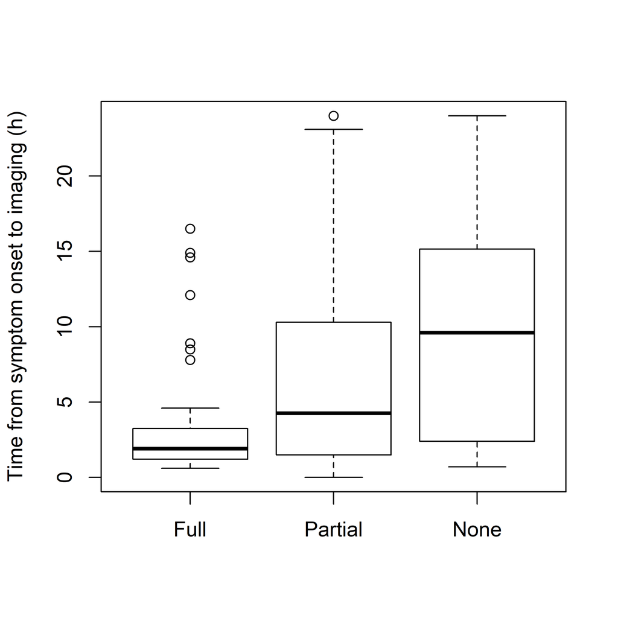

### What is the association between reperfusion and recanalization?

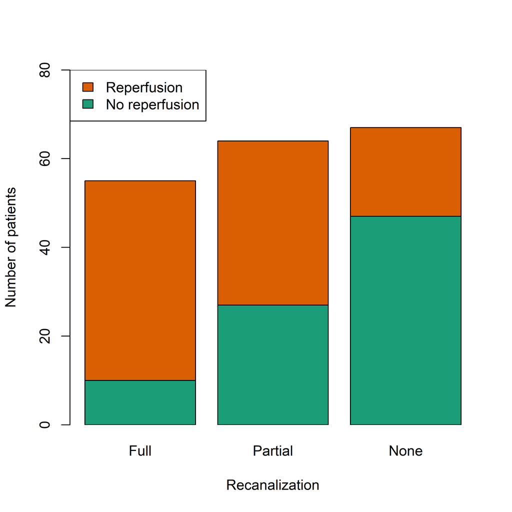

|  | Recanalization Full | Recanalization Partial | Recanalization None |
| --- | --- | --- | --- |
| **Reperfusion** |  |  |  |
| No | 10 | 27 | 47 |
| Yes | 45 | 37 | 20 |

```
##
##  Pearson's Chi-squared test
##
## data:  table(allpts$reperf, allpts$Rekan)
## X-squared = 33.286, df = 2, p-value = 5.917e-08
```

There is a statistically significant difference in the prevalence of reperfusion between the recanalization groups (i.e. reperfusion is associated with recanalization grade).

### Is there a difference in the extent of reperfusion between patients with anterior and posterior circulation strokes?

Models (1) & (2) - in non-recanalizers  
Models (3) & (4) - in recanalizers  
Models (2) & (4) - adjusted for IV tPA  
Models (1) & (3) - not adjusted for IV tPA

**Note: the second iteration of “iv_tPRYes” in the table below refers to the interaction between circulation + IV tPA**

|  | *Dependent variable:* |  |  |  |
| --- | --- | --- | --- | --- |
|  | relTmax_4_change |  | relTmax_4_change |  |
|  | (1) | (2) | (3) | (4) |
| circulationPosterior | 29.520* (16.608) | 11.789 (19.337) |  |  |
|  | t = 1.777 | t = 0.610 |  |  |
|  | p = 0.081 | p = 0.545 |  |  |
| iv_tPRYes |  | -20.471 (14.969) |  |  |
|  |  | t = -1.368 |  |  |
|  |  | p = 0.177 |  |  |
| iv_tPRYes |  | 65.324* (33.648) |  |  |
|  |  | t = 1.941 |  |  |
|  |  | p = 0.057 |  |  |
| circulationPosterior |  |  | 9.670 (8.946) | -4.497 (12.173) |
|  |  |  | t = 1.081 | t = -0.369 |
|  |  |  | p = 0.282 | p = 0.713 |
| iv_tPRYes |  |  |  | -17.255** (7.925) |
|  |  |  |  | t = -2.177 |
|  |  |  |  | p = 0.032 |
| iv_tPRYes |  |  |  | 26.648 (17.689) |
|  |  |  |  | t = 1.506 |
|  |  |  |  | p = 0.135 |
| Constant | -33.737*** (7.392) | -27.465*** (8.692) | -71.274*** (6.148) | -61.023*** (8.142) |
|  | t = -4.564 | t = -3.160 | t = -11.593 | t = -7.494 |
|  | p = 0.00003 | p = 0.003 | p = 0.000 | p = 0.000 |
| Observations | 67 | 67 | 119 | 119 |
| R<sup>2</sup> | 0.059 | 0.118 | 0.013 | 0.068 |
| Adjusted R<sup>2</sup> | 0.045 | 0.075 | 0.005 | 0.044 |
| Residual Std. Error | 56.562 (df = 65) | 55.023 (df = 63) | 27.457 (df = 117) | 27.849 (df = 115) |
| *Note:* | p<0.1; p<0.05; p<0.01 |  |  |  |

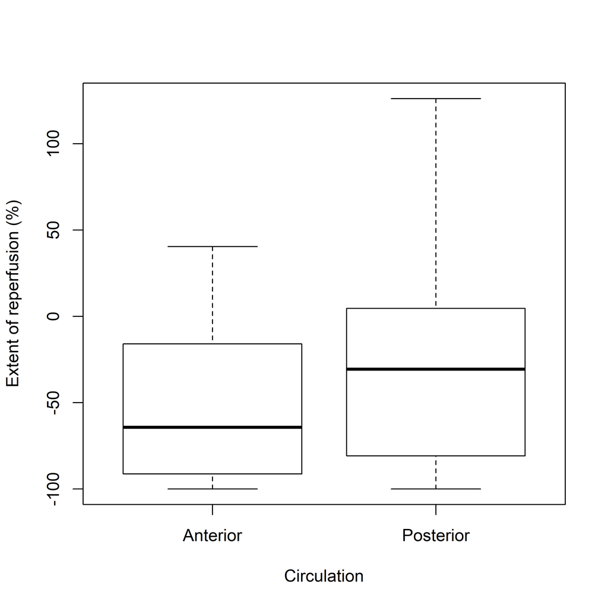

### Predictors of extent of reperfusion

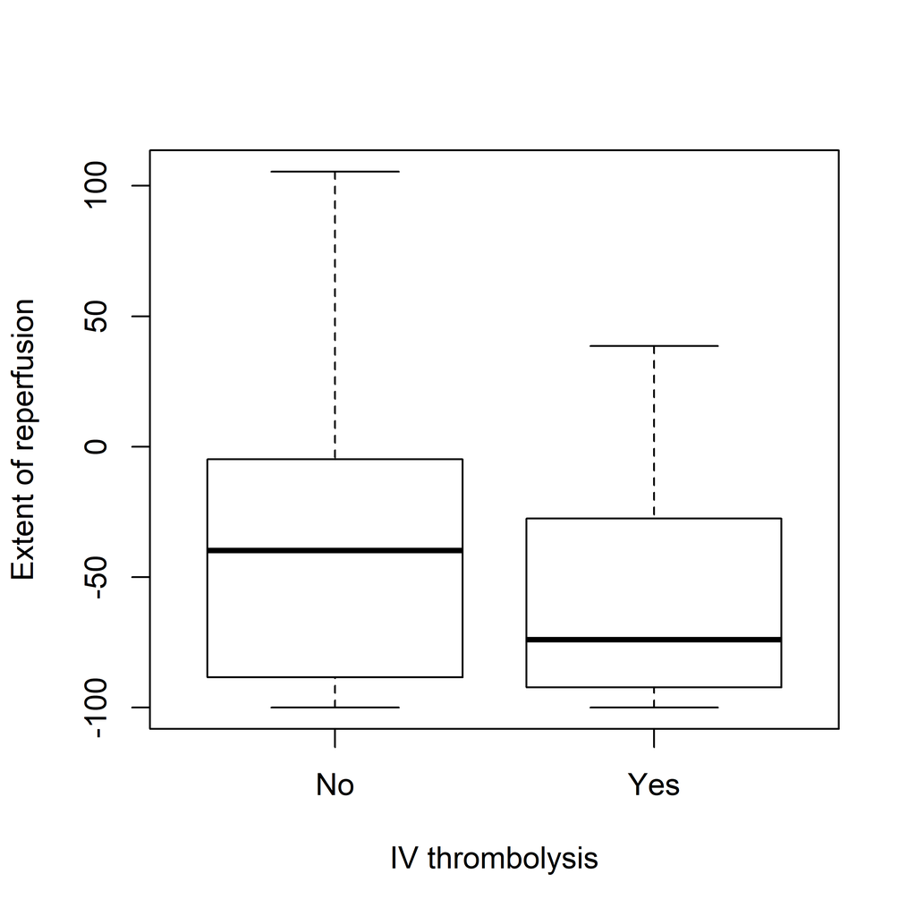

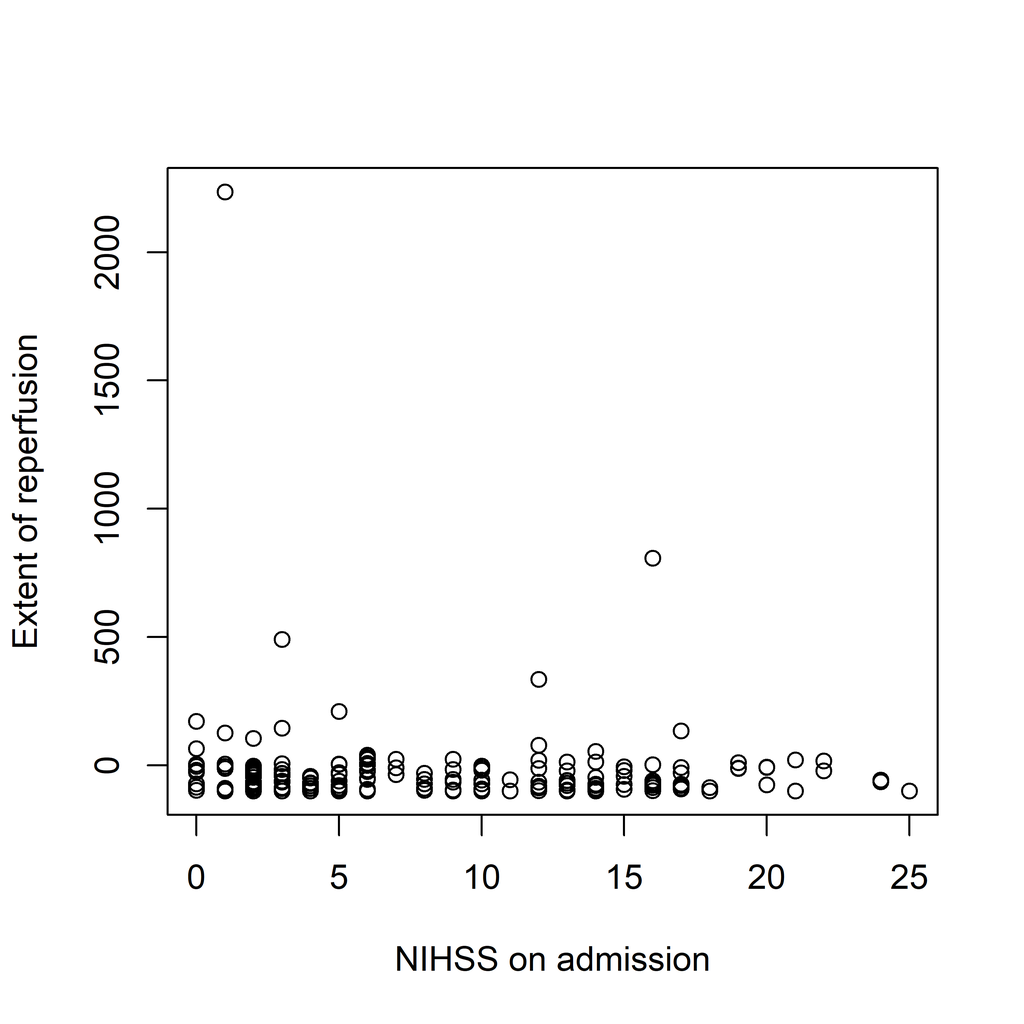

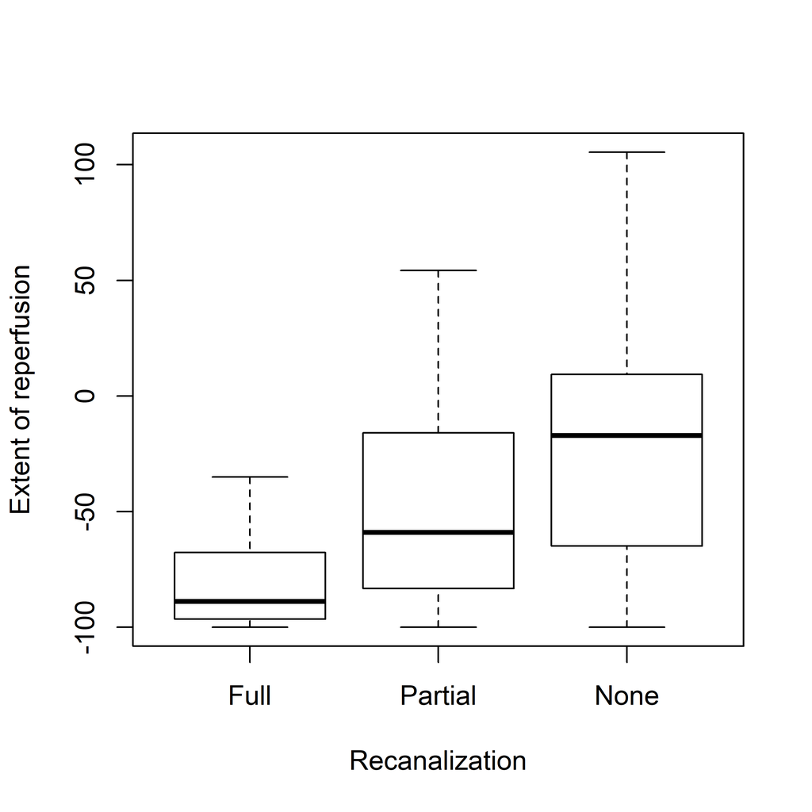

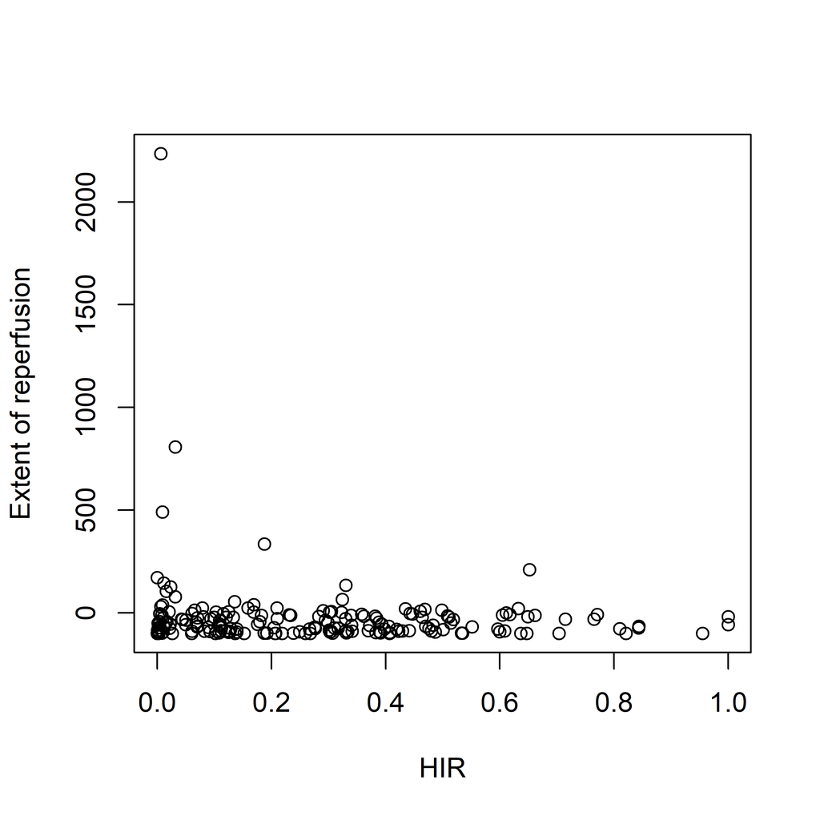

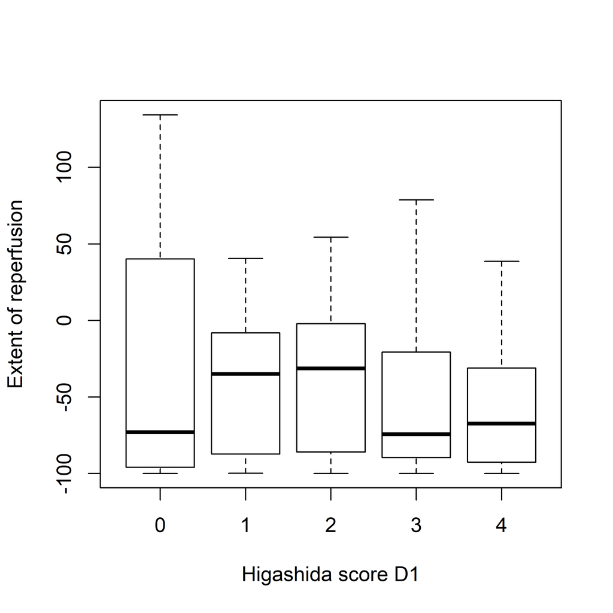

|  | *Dependent variable:* |  |  |  |
| --- | --- | --- | --- | --- |
|  | relTmax_4_change |  |  |  |
|  | (1) | (2) | (3) | (4) |
| NIHSS_ad | 0.295 (0.540) | -0.088 (0.481) | -0.072 (0.529) | -0.500 (0.473) |
|  | t = 0.546 | t = -0.183 | t = -0.137 | t = -1.057 |
|  | p = 0.586 | p = 0.855 | p = 0.892 | p = 0.293 |
| iv_tPRYes | -19.347*** (6.910) | -6.480 (6.742) | -5.773 (6.829) | -4.164 (6.925) |
|  | t = -2.800 | t = -0.961 | t = -0.845 | t = -0.601 |
|  | p = 0.006 | p = 0.338 | p = 0.400 | p = 0.549 |
| HIR1 |  |  | -14.176 (27.137) |  |
|  |  |  | t = -0.522 |  |
|  |  |  | p = 0.603 |  |
| higashida_D11 |  |  |  | 22.665** (10.244) |
|  |  |  |  | t = 2.212 |
|  |  |  |  | p = 0.029 |
| higashida_D12 |  |  |  | 26.456*** (9.503) |
|  |  |  |  | t = 2.784 |
|  |  |  |  | p = 0.006 |
| higashida_D13 |  |  |  | 18.615** (7.311) |
|  |  |  |  | t = 2.546 |
|  |  |  |  | p = 0.012 |
| higashida_D14 |  |  |  | 20.899** (8.348) |
|  |  |  |  | t = 2.503 |
|  |  |  |  | p = 0.014 |
| RekanPartial |  | 22.807*** (6.700) | 18.438 (11.218) | 48.100*** (1.894) |
|  |  | t = 3.404 | t = 1.644 | t = 25.402 |
|  |  | p = 0.001 | p = 0.103 | p = 0.000 |
| RekanNone |  | 45.283*** (8.147) | 34.251** (15.555) | 14.461** (6.154) |
|  |  | t = 5.559 | t = 2.202 | t = 2.350 |
|  |  | p = 0.00000 | p = 0.029 | p = 0.020 |
| HIR1:RekanPartial |  |  | 15.146 (29.550) |  |
|  |  |  | t = 0.513 |  |
|  |  |  | p = 0.609 |  |
| HIR1:RekanNone |  |  | 36.996 (39.597) |  |
|  |  |  | t = 0.934 |  |
|  |  |  | p = 0.352 |  |
| higashida_D11:RekanPartial |  |  |  | -8.230 (18.412) |
|  |  |  |  | t = -0.447 |
|  |  |  |  | p = 0.656 |
| higashida_D12:RekanPartial |  |  |  | -1.305 (13.741) |
|  |  |  |  | t = -0.095 |
|  |  |  |  | p = 0.925 |
| higashida_D13:RekanPartial |  |  |  | -32.085*** (10.689) |
|  |  |  |  | t = -3.002 |
|  |  |  |  | p = 0.004 |
| higashida_D14:RekanPartial |  |  |  | -38.735*** (9.260) |
|  |  |  |  | t = -4.183 |
|  |  |  |  | p = 0.00005 |
| higashida_D11:RekanNone |  |  |  | 51.327*** (14.821) |
|  |  |  |  | t = 3.463 |
|  |  |  |  | p = 0.001 |
| higashida_D12:RekanNone |  |  |  | 41.142*** (15.097) |
|  |  |  |  | t = 2.725 |
|  |  |  |  | p = 0.008 |
| higashida_D13:RekanNone |  |  |  | 18.505 (14.606) |
|  |  |  |  | t = 1.267 |
|  |  |  |  | p = 0.207 |
| higashida_D14:RekanNone |  |  |  | 14.995 (17.555) |
|  |  |  |  | t = 0.854 |
|  |  |  |  | p = 0.395 |
| Constant | -47.628*** (6.767) | -73.278*** (6.337) | -69.425*** (8.622) | -93.818*** (6.317) |
|  | t = -7.038 | t = -11.564 | t = -8.053 | t = -14.852 |
|  | p = 0.000 | p = 0.000 | p = 0.000 | p = 0.000 |
| Observations | 186 | 186 | 186 | 185 |
| R<sup>2</sup> | 0.043 | 0.206 | 0.205 | 0.332 |
| Adjusted R<sup>2</sup> | 0.033 | 0.188 | 0.174 | 0.268 |
| Residual Std. Error | 45.321 (df = 183) | 36.325 (df = 181) | 37.318 (df = 178) | 33.757 (df = 168) |
| *Note:* | p<0.1; p<0.05; p<0.01 |  |  |  |

**1 vs 2**

| Statistic | N | Mean | St. Dev. | Min | Pctl(25) | Pctl(75) | Max |
| --- | --- | --- | --- | --- | --- | --- | --- |
| pseudoDf | 2 | 182.000 | 1.414 | 181 | 181.5 | 182.5 | 183 |
| Test.Stat | 1 | 33.636 |  | 33.636 | 33.636 | 33.636 | 33.636 |
| Df | 1 | 2.000 |  | 2.000 | 2.000 | 2.000 | 2.000 |
| Pr(> chisq) | 1 | 0.00000 |  | 0.00000 | 0.00000 | 0.00000 | 0.00000 |

**1 vs 3**

| Statistic | N | Mean | St. Dev. | Min | Pctl(25) | Pctl(75) | Max |
| --- | --- | --- | --- | --- | --- | --- | --- |
| pseudoDf | 2 | 180.500 | 3.536 | 178 | 179.2 | 181.8 | 183 |
| Test.Stat | 1 | 41.547 |  | 41.547 | 41.547 | 41.547 | 41.547 |
| Df | 1 | 5.000 |  | 5.000 | 5.000 | 5.000 | 5.000 |
| Pr(> chisq) | 1 | 0.00000 |  | 0.00000 | 0.00000 | 0.00000 | 0.00000 |

**1 vs 4**

| Statistic | N | Mean | St. Dev. | Min | Pctl(25) | Pctl(75) | Max |
| --- | --- | --- | --- | --- | --- | --- | --- |
| pseudoDf | 2 | 175.000 | 9.899 | 168 | 171.5 | 178.5 | 182 |
| Test.Stat | 1 | 2,432,714,194,772,356.000 |  | 2,432,714,194,772,356.000 | 2,432,714,194,772,356.000 | 2,432,714,194,772,356.000 | 2,432,714,194,772,356.000 |
| Df | 1 | 14.000 |  | 14.000 | 14.000 | 14.000 | 14.000 |
| Pr(> chisq) | 1 | 0.000 |  | 0.000 | 0.000 | 0.000 | 0.000 |

### Predictors of clinical outcome

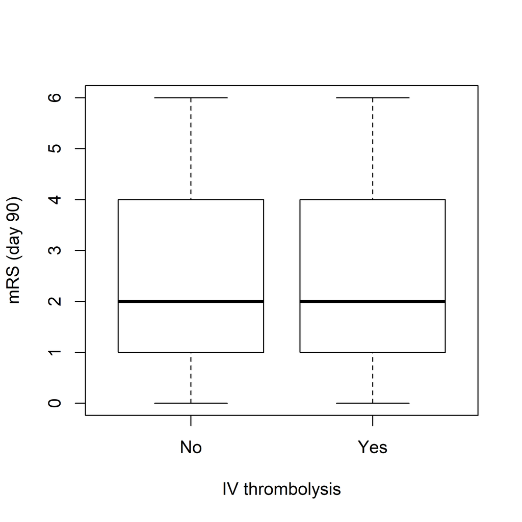

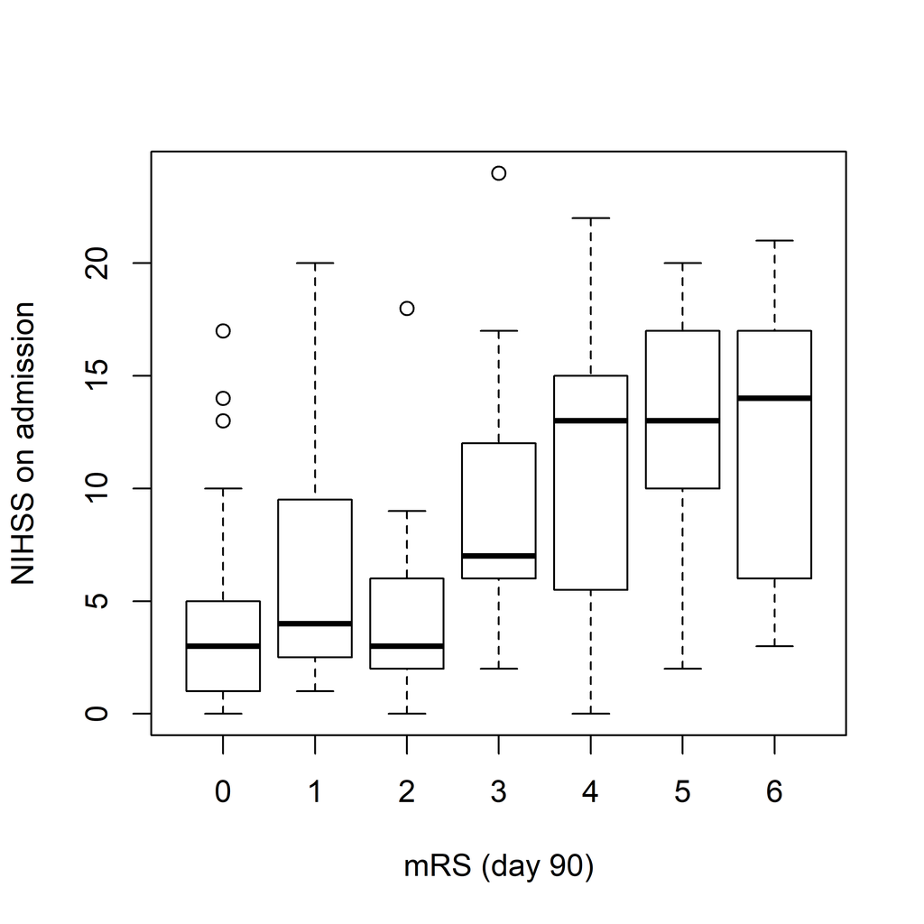

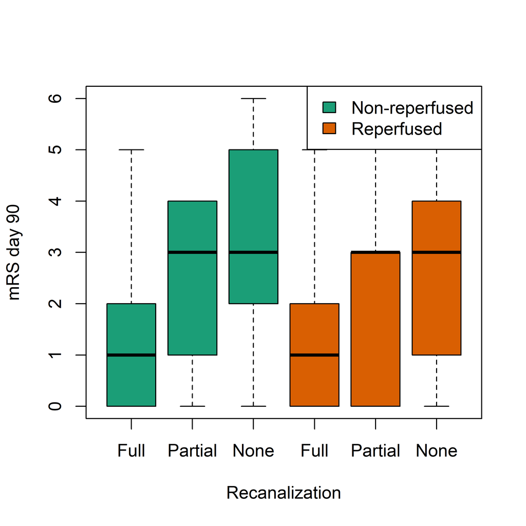

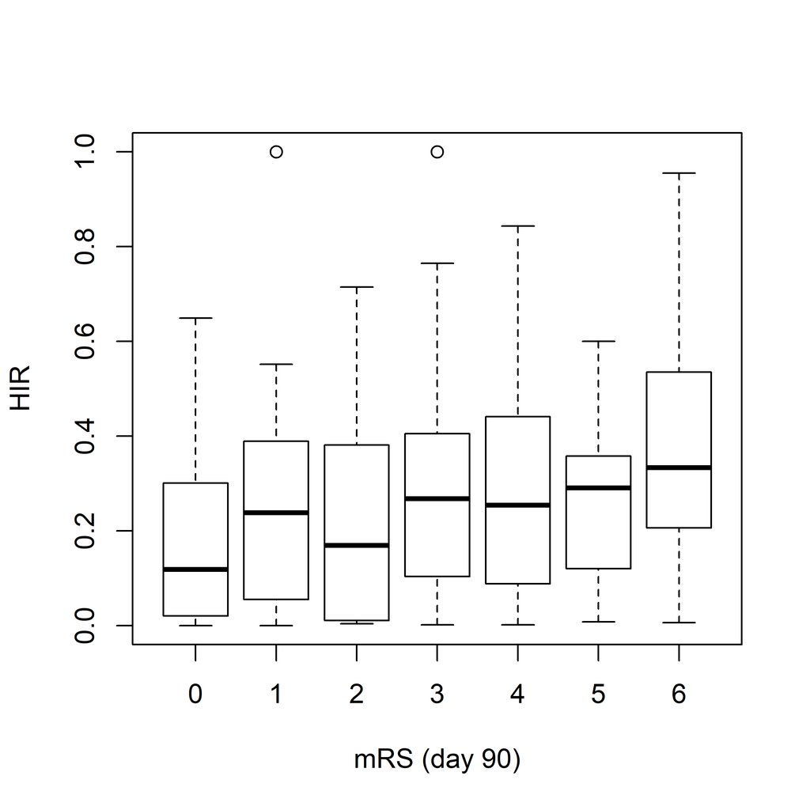

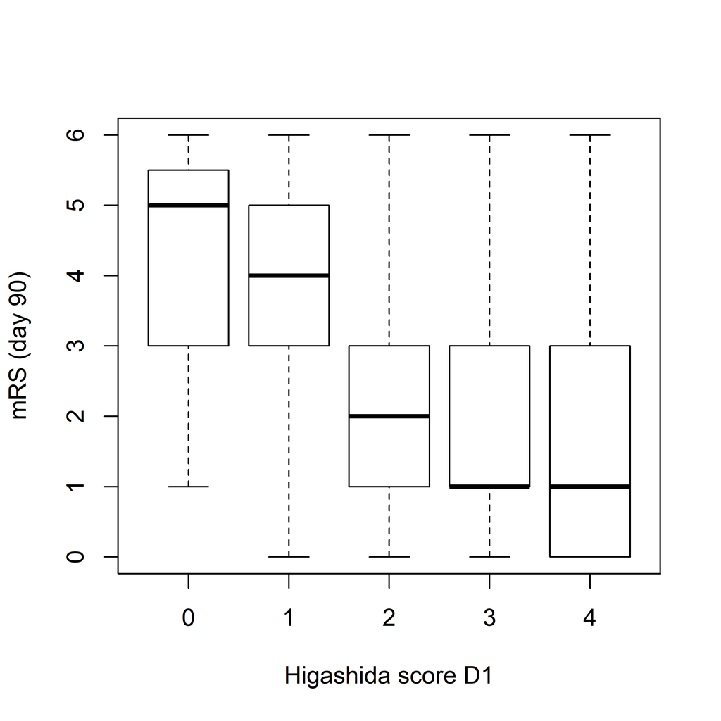

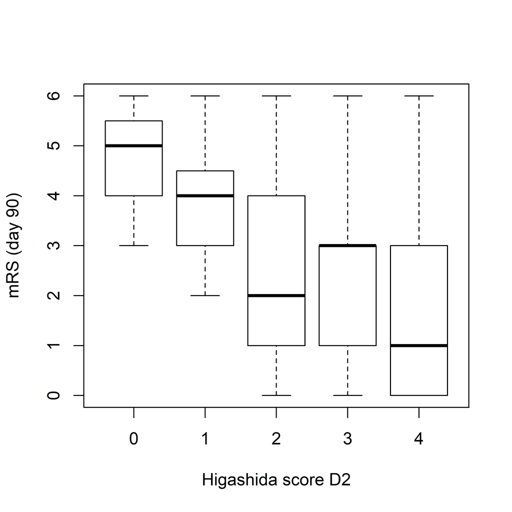

|  | *Dependent variable:* |  |  |  |  |
| --- | --- | --- | --- | --- | --- |
|  | mRS_d90 |  |  |  |  |
|  | (1) | (2) | (3) | (4) | (5) |
| NIHSS_ad | 0.179*** (0.028) | 0.178*** (0.024) | 0.160*** (0.026) | 0.148*** (0.030) | 0.156*** (0.031) |
|  | t = 6.363 | t = 7.460 | t = 6.155 | t = 4.881 | t = 5.106 |
|  | p = 0.000 | p = 0.000 | p = 0.000 | p = 0.00001 | p = 0.00001 |
| iv_tPRYes | -0.778*** (0.285) | -0.597** (0.272) | -0.533** (0.260) | -0.665** (0.294) | -0.587** (0.254) |
|  | t = -2.730 | t = -2.195 | t = -2.051 | t = -2.258 | t = -2.316 |
|  | p = 0.008 | p = 0.030 | p = 0.043 | p = 0.026 | p = 0.023 |
| HIR1 |  |  | 1.475 (0.993) |  |  |
|  |  |  | t = 1.485 |  |  |
|  |  |  | p = 0.140 |  |  |
| higashida_D11 |  |  |  | 0.358 (2.023) |  |
|  |  |  |  | t = 0.177 |  |
|  |  |  |  | p = 0.860 |  |
| higashida_D12 |  |  |  | -0.270 (0.544) |  |
|  |  |  |  | t = -0.496 |  |
|  |  |  |  | p = 0.621 |  |
| higashida_D13 |  |  |  | -0.364 (0.345) |  |
|  |  |  |  | t = -1.054 |  |
|  |  |  |  | p = 0.294 |  |
| higashida_D14 |  |  |  | -0.769* (0.433) |  |
|  |  |  |  | t = -1.776 |  |
|  |  |  |  | p = 0.079 |  |
| higashida_D21 |  |  |  |  | -1.744 (2.936) |
|  |  |  |  |  | t = -0.594 |
|  |  |  |  |  | p = 0.554 |
| higashida_D22 |  |  |  |  | -0.001 (1.462) |
|  |  |  |  |  | t = -0.001 |
|  |  |  |  |  | p = 1.000 |
| higashida_D23 |  |  |  |  | -1.793* (1.011) |

[output cut: 80 more lines]

**1 vs 2**

| Statistic | N | Mean | St. Dev. | Min | Pctl(25) | Pctl(75) | Max |
| --- | --- | --- | --- | --- | --- | --- | --- |
| pseudoDf | 2 | 143.500 | 3.536 | 141 | 142.2 | 144.8 | 146 |
| Test.Stat | 1 | 25.981 |  | 25.981 | 25.981 | 25.981 | 25.981 |
| Df | 1 | 5.000 |  | 5.000 | 5.000 | 5.000 | 5.000 |
| Pr(> chisq) | 1 | 0.0001 |  | 0.0001 | 0.0001 | 0.0001 | 0.0001 |

**1 vs 3**

| Statistic | N | Mean | St. Dev. | Min | Pctl(25) | Pctl(75) | Max |
| --- | --- | --- | --- | --- | --- | --- | --- |
| pseudoDf | 2 | 143.500 | 3.536 | 141 | 142.2 | 144.8 | 146 |
| Test.Stat | 1 | 29.929 |  | 29.929 | 29.929 | 29.929 | 29.929 |
| Df | 1 | 5.000 |  | 5.000 | 5.000 | 5.000 | 5.000 |
| Pr(> chisq) | 1 | 0.00002 |  | 0.00002 | 0.00002 | 0.00002 | 0.00002 |

**1 vs 4**

| Statistic | N | Mean | St. Dev. | Min | Pctl(25) | Pctl(75) | Max |
| --- | --- | --- | --- | --- | --- | --- | --- |
| pseudoDf | 2 | 139.000 | 9.899 | 132 | 135.5 | 142.5 | 146 |
| Test.Stat | 1 | 2,449.850 |  | 2,449.850 | 2,449.850 | 2,449.850 | 2,449.850 |
| Df | 1 | 14.000 |  | 14.000 | 14.000 | 14.000 | 14.000 |
| Pr(> chisq) | 1 | 0.000 |  | 0.000 | 0.000 | 0.000 | 0.000 |

### Predictors of absolute infarct growth (D1 - D2)

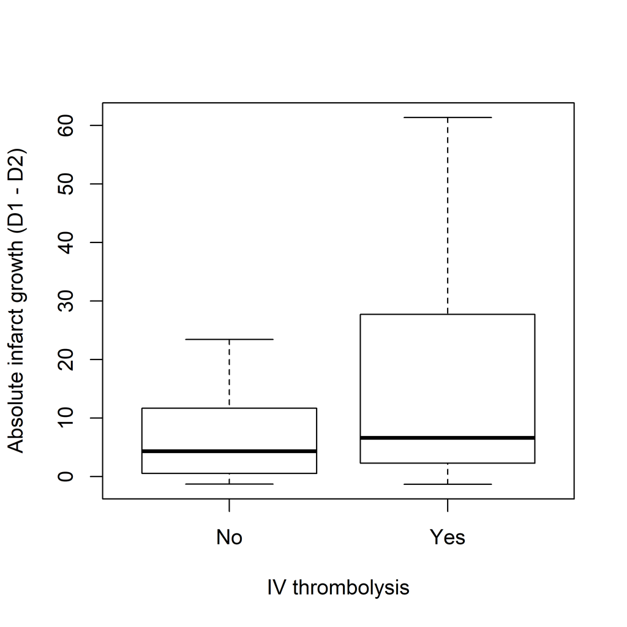

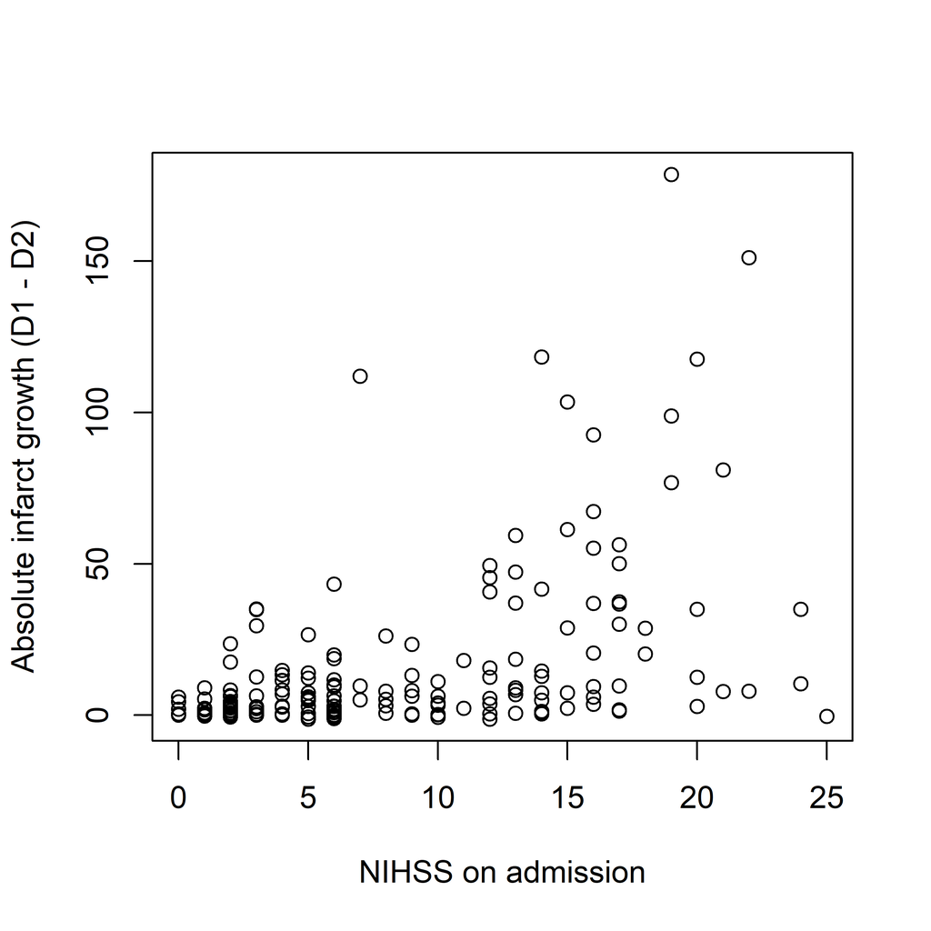

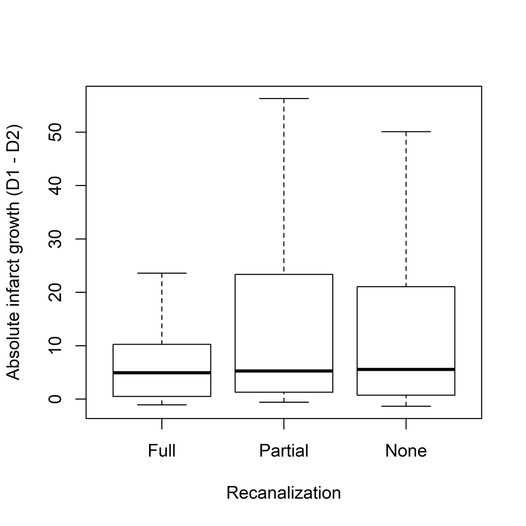

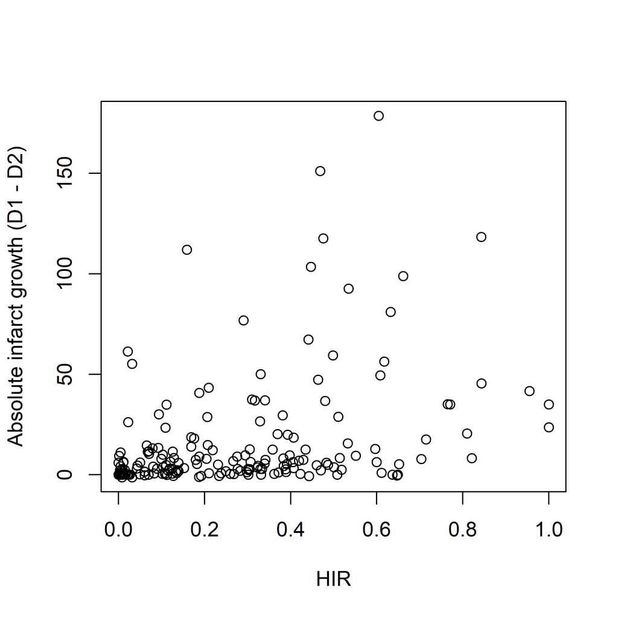

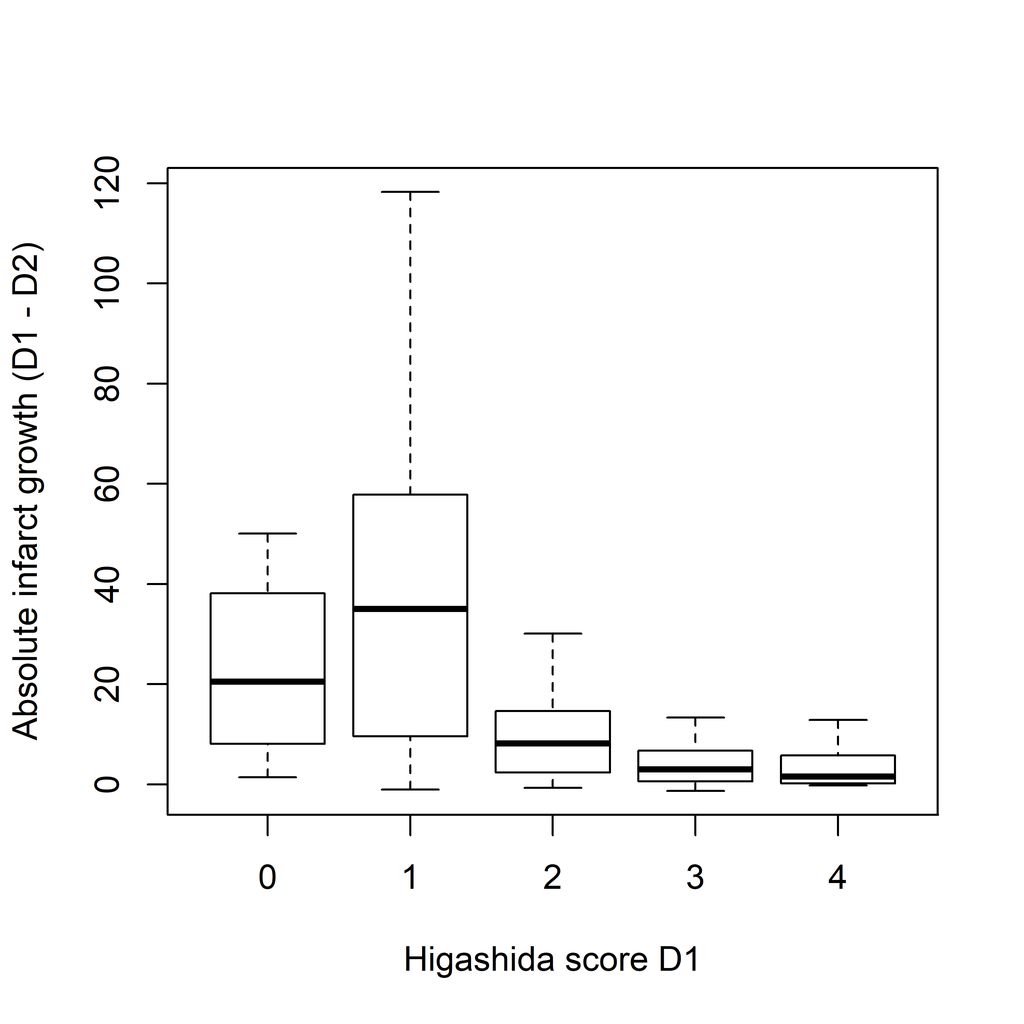

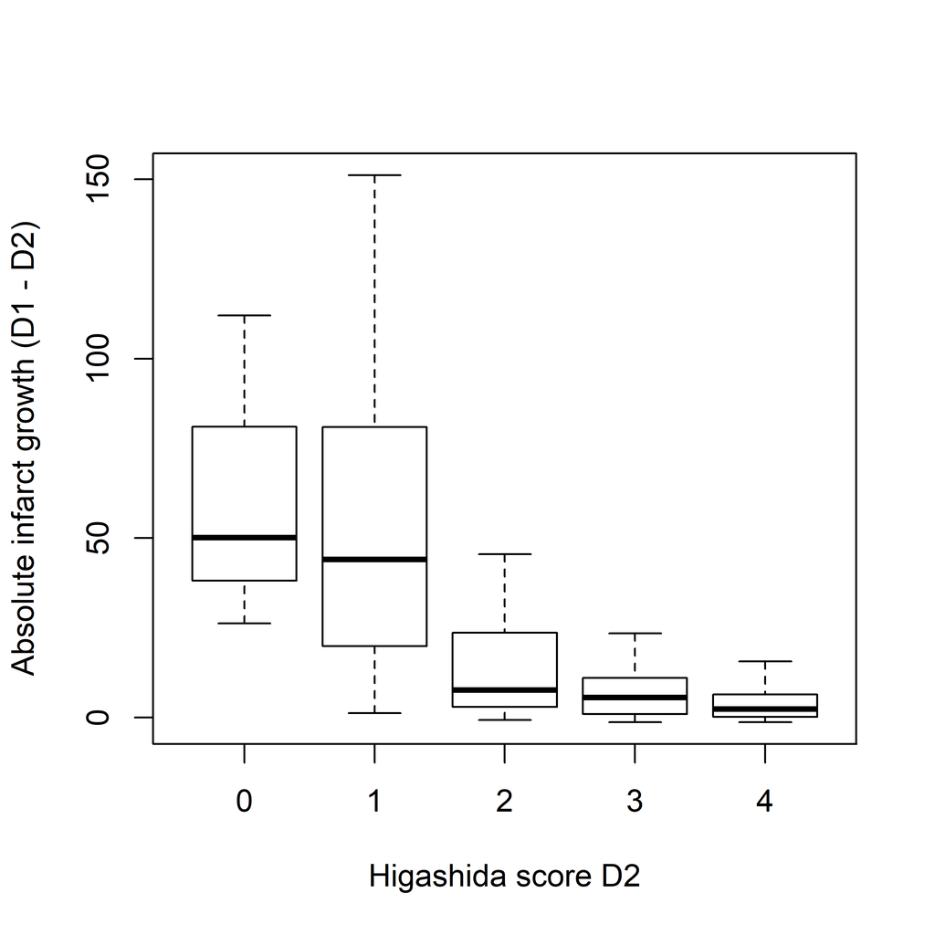

|  | *Dependent variable:* |  |  |  |  |
| --- | --- | --- | --- | --- | --- |
|  | DWIgrowth |  |  |  |  |
|  | (1) | (2) | (3) | (4) | (5) |
| NIHSS_ad | 0.311*** (0.103) | 0.332*** (0.118) | 0.253** (0.118) | 0.265** (0.107) | 0.195** (0.098) |
|  | t = 3.028 | t = 2.820 | t = 2.146 | t = 2.482 | t = 1.978 |
|  | p = 0.003 | p = 0.006 | p = 0.034 | p = 0.015 | p = 0.050 |
| iv_tPRYes | -0.379 (0.961) | -0.758 (1.121) | -0.860 (1.111) | -1.014 (0.993) | -0.088 (1.171) |
|  | t = -0.395 | t = -0.676 | t = -0.774 | t = -1.021 | t = -0.075 |
|  | p = 0.694 | p = 0.500 | p = 0.440 | p = 0.309 | p = 0.941 |
| HIR1 |  |  | 7.045 (7.116) |  |  |
|  |  |  | t = 0.990 |  |  |
|  |  |  | p = 0.324 |  |  |
| higashida_D11 |  |  |  | -7.783 (6.233) |  |
|  |  |  |  | t = -1.249 |  |
|  |  |  |  | p = 0.214 |  |
| higashida_D12 |  |  |  | -9.877*** (1.523) |  |
|  |  |  |  | t = -6.484 |  |
|  |  |  |  | p = 0.000 |  |
| higashida_D13 |  |  |  | -11.236*** (1.349) |  |
|  |  |  |  | t = -8.329 |  |
|  |  |  |  | p = 0.000 |  |
| higashida_D14 |  |  |  | -12.597*** (1.208) |  |
|  |  |  |  | t = -10.427 |  |
|  |  |  |  | p = 0.000 |  |
| higashida_D21 |  |  |  |  | -100.104*** (5.751) |
|  |  |  |  |  | t = -17.408 |
|  |  |  |  |  | p = 0.000 |
| higashida_D22 |  |  |  |  | -99.524*** (9.003) |
|  |  |  |  |  | t = -11.054 |
|  |  |  |  |  | p = 0.000 |
| higashida_D23 |  |  |  |  | -109.996*** (1.610) |

[output cut: 80 more lines]

**1 vs 2**

| Statistic | N | Mean | St. Dev. | Min | Pctl(25) | Pctl(75) | Max |
| --- | --- | --- | --- | --- | --- | --- | --- |
| pseudoDf | 2 | 180.500 | 3.536 | 178 | 179.2 | 181.8 | 183 |
| Test.Stat | 1 | 1.773 |  | 1.773 | 1.773 | 1.773 | 1.773 |
| Df | 1 | 5.000 |  | 5.000 | 5.000 | 5.000 | 5.000 |
| Pr(> chisq) | 1 | 0.880 |  | 0.880 | 0.880 | 0.880 | 0.880 |

**1 vs 3**

| Statistic | N | Mean | St. Dev. | Min | Pctl(25) | Pctl(75) | Max |
| --- | --- | --- | --- | --- | --- | --- | --- |
| pseudoDf | 2 | 180.500 | 3.536 | 178 | 179.2 | 181.8 | 183 |
| Test.Stat | 1 | 6.974 |  | 6.974 | 6.974 | 6.974 | 6.974 |
| Df | 1 | 5.000 |  | 5.000 | 5.000 | 5.000 | 5.000 |
| Pr(> chisq) | 1 | 0.223 |  | 0.223 | 0.223 | 0.223 | 0.223 |

**1 vs 4**

| Statistic | N | Mean | St. Dev. | Min | Pctl(25) | Pctl(75) | Max |
| --- | --- | --- | --- | --- | --- | --- | --- |
| pseudoDf | 2 | 175.000 | 9.899 | 168 | 171.5 | 178.5 | 182 |
| Test.Stat | 1 | 3,131,684,848,428.000 |  | 3,131,684,848,428.000 | 3,131,684,848,428.000 | 3,131,684,848,428.000 | 3,131,684,848,428.000 |
| Df | 1 | 14.000 |  | 14.000 | 14.000 | 14.000 | 14.000 |
| Pr(> chisq) | 1 | 0.000 |  | 0.000 | 0.000 | 0.000 | 0.000 |

### Predictors of absolute infarct growth (D1 - D5)

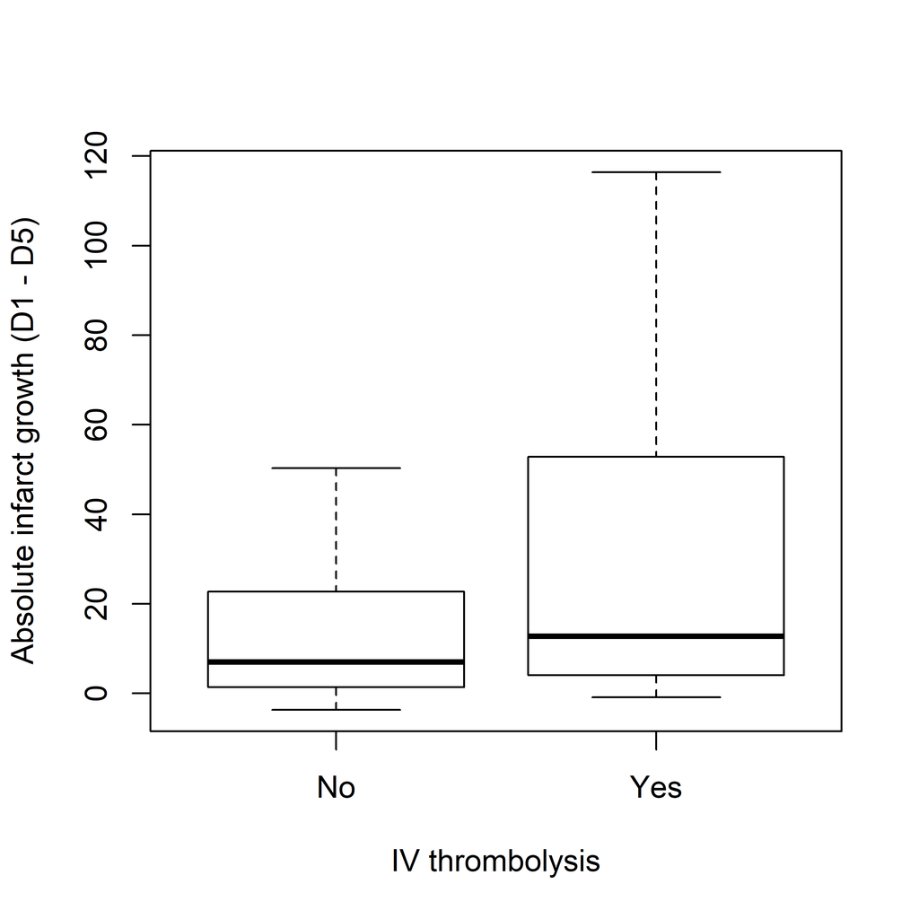

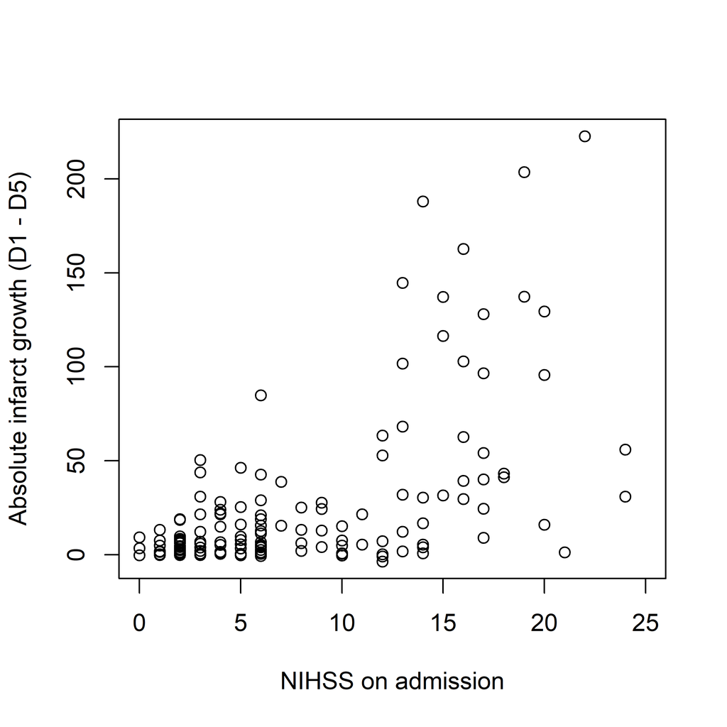

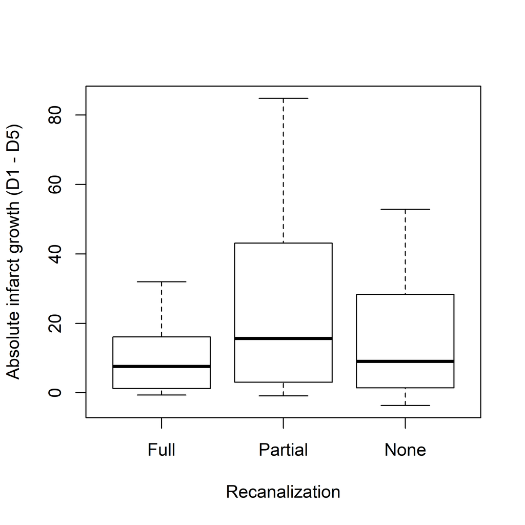

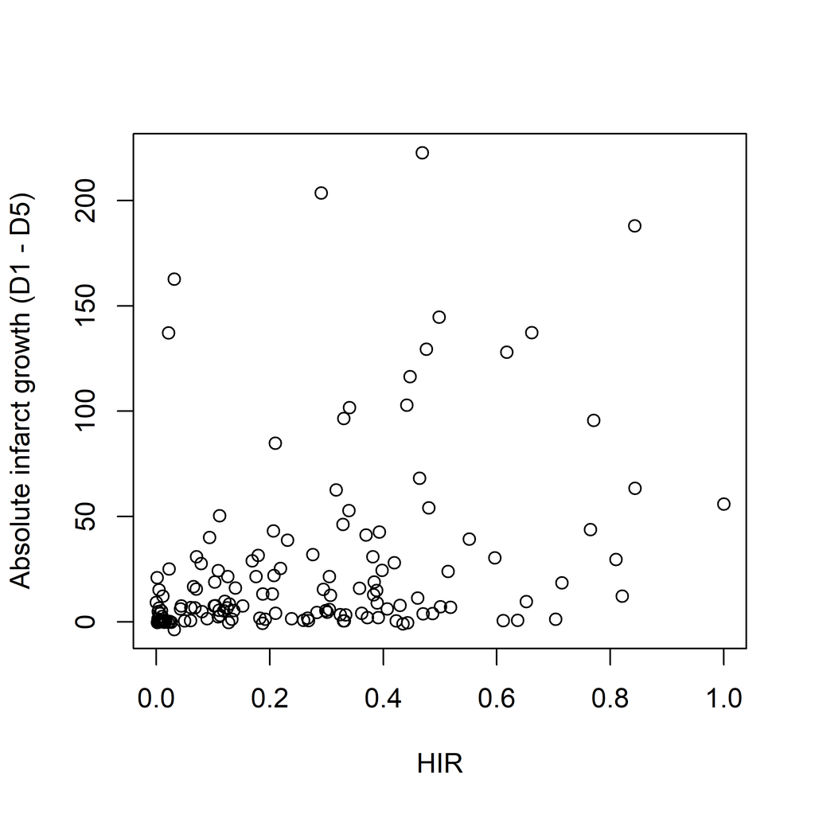

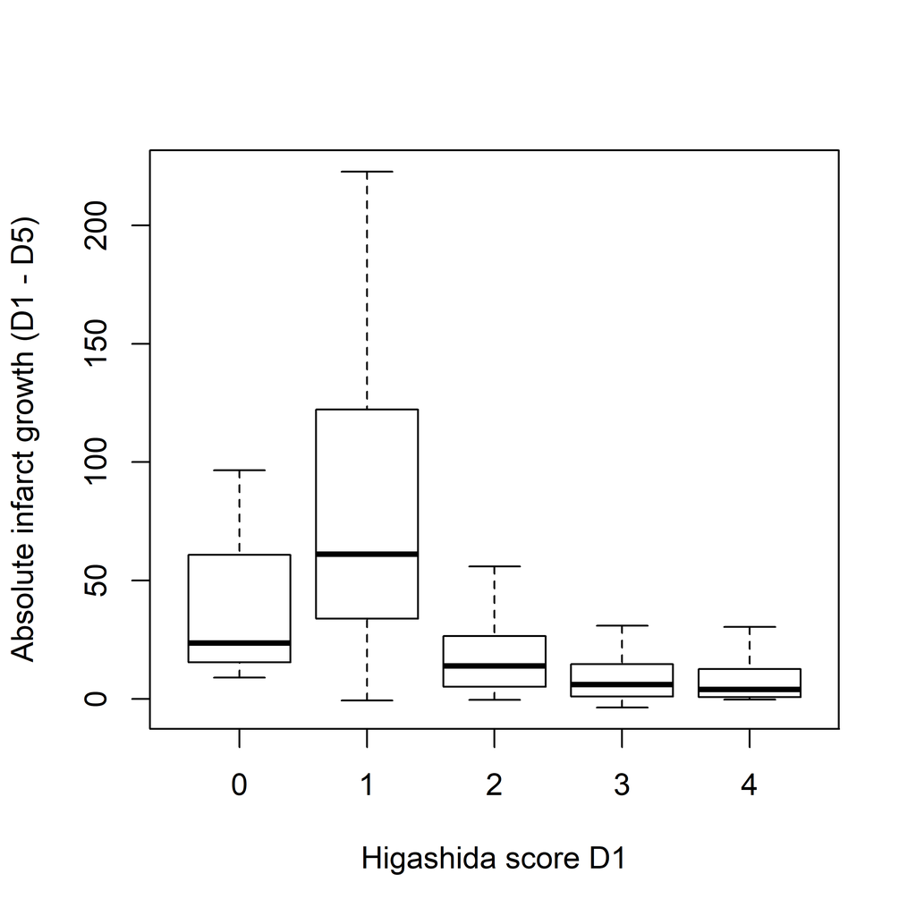

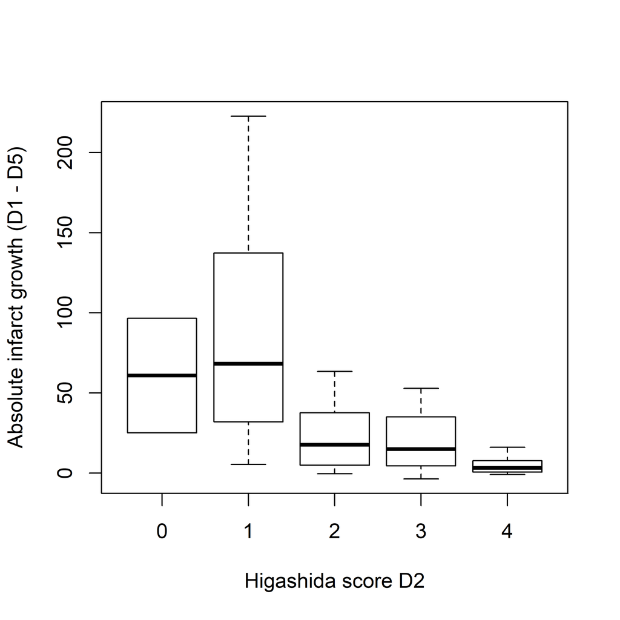

|  | *Dependent variable:* |  |  |  |  |
| --- | --- | --- | --- | --- | --- |
|  | infarct_growth_D5FLAIR |  |  |  |  |
|  | (1) | (2) | (3) | (4) | (5) |
| NIHSS_ad | 1.290*** (0.226) | 1.304*** (0.245) | 1.121*** (0.248) | 1.250*** (0.247) | 0.619** (0.242) |
|  | t = 5.719 | t = 5.334 | t = 4.513 | t = 5.053 | t = 2.558 |
|  | p = 0.00000 | p = 0.00000 | p = 0.00002 | p = 0.00001 | p = 0.012 |
| iv_tPRYes | -0.539 (2.501) | 0.447 (2.816) | -0.019 (2.760) | 1.005 (2.937) | 1.171 (2.594) |
|  | t = -0.216 | t = 0.159 | t = -0.007 | t = 0.342 | t = 0.451 |
|  | p = 0.830 | p = 0.875 | p = 0.995 | p = 0.733 | p = 0.653 |
| HIR1 |  |  | 6.504 (11.099) |  |  |
|  |  |  | t = 0.586 |  |  |
|  |  |  | p = 0.559 |  |  |
| higashida_D11 |  |  |  | -4.786 (14.714) |  |
|  |  |  |  | t = -0.325 |  |
|  |  |  |  | p = 0.746 |  |
| higashida_D12 |  |  |  | -14.317 (13.568) |  |
|  |  |  |  | t = -1.055 |  |
|  |  |  |  | p = 0.294 |  |
| higashida_D13 |  |  |  | -14.646 (13.816) |  |
|  |  |  |  | t = -1.060 |  |
|  |  |  |  | p = 0.292 |  |
| higashida_D14 |  |  |  | -17.022 (13.670) |  |
|  |  |  |  | t = -1.245 |  |
|  |  |  |  | p = 0.216 |  |
| higashida_D21 |  |  |  |  | -54.618*** (14.988) |
|  |  |  |  |  | t = -3.644 |
|  |  |  |  |  | p = 0.0004 |
| higashida_D22 |  |  |  |  | -57.690*** (13.882) |
|  |  |  |  |  | t = -4.156 |
|  |  |  |  |  | p = 0.0001 |
| higashida_D23 |  |  |  |  | -75.494*** (13.701) |

[output cut: 80 more lines]

**1 vs 2**

| Statistic | N | Mean | St. Dev. | Min | Pctl(25) | Pctl(75) | Max |
| --- | --- | --- | --- | --- | --- | --- | --- |
| pseudoDf | 2 | 135.500 | 3.536 | 133 | 134.2 | 136.8 | 138 |
| Test.Stat | 1 | 0.960 |  | 0.960 | 0.960 | 0.960 | 0.960 |
| Df | 1 | 5.000 |  | 5.000 | 5.000 | 5.000 | 5.000 |
| Pr(> chisq) | 1 | 0.966 |  | 0.966 | 0.966 | 0.966 | 0.966 |

**1 vs 3**

| Statistic | N | Mean | St. Dev. | Min | Pctl(25) | Pctl(75) | Max |
| --- | --- | --- | --- | --- | --- | --- | --- |
| pseudoDf | 2 | 135.500 | 3.536 | 133 | 134.2 | 136.8 | 138 |
| Test.Stat | 1 | 8.729 |  | 8.729 | 8.729 | 8.729 | 8.729 |
| Df | 1 | 5.000 |  | 5.000 | 5.000 | 5.000 | 5.000 |
| Pr(> chisq) | 1 | 0.120 |  | 0.120 | 0.120 | 0.120 | 0.120 |

**1 vs 4**

| Statistic | N | Mean | St. Dev. | Min | Pctl(25) | Pctl(75) | Max |
| --- | --- | --- | --- | --- | --- | --- | --- |
| pseudoDf | 2 | 131.000 | 9.899 | 124 | 127.5 | 134.5 | 138 |
| Test.Stat | 1 | 270.159 |  | 270.159 | 270.159 | 270.159 | 270.159 |
| Df | 1 | 14.000 |  | 14.000 | 14.000 | 14.000 | 14.000 |
| Pr(> chisq) | 1 | 0.000 |  | 0.000 | 0.000 | 0.000 | 0.000 |

### Predictors of collateral flow defined by Higashida score

|  | *Dependent variable:* |  |  |
| --- | --- | --- | --- |
|  | higashida_D1 |  |  |
|  | (1) | (2) | (3) |
| NIHSS_ad | -0.070*** (0.012) | -0.078*** (0.011) | -0.052*** (0.011) |
|  | t = -5.644 | t = -7.108 | t = -4.935 |
|  | p = 0.00000 | p = 0.000 | p = 0.00001 |
| RekanPartial |  | 0.318 (0.375) | 0.279 (0.371) |
|  |  | t = 0.849 | t = 0.752 |
|  |  | p = 0.397 | p = 0.453 |
| RekanNone |  | 0.275 (0.367) | 0.227 (0.366) |
|  |  | t = 0.750 | t = 0.621 |
|  |  | p = 0.455 | p = 0.536 |
| reperfYes |  | 0.567 (0.381) | 0.588 (0.381) |
|  |  | t = 1.486 | t = 1.541 |
|  |  | p = 0.140 | p = 0.126 |
| HIR1 |  |  | -1.674*** (0.318) |
|  |  |  | t = -5.264 |
|  |  |  | p = 0.00000 |
| RekanPartial:reperfYes |  | 0.232 (0.450) | 0.185 (0.439) |
|  |  | t = 0.516 | t = 0.420 |
|  |  | p = 0.607 | p = 0.675 |
| RekanNone:reperfYes |  | 0.175 (0.460) | -0.045 (0.456) |
|  |  | t = 0.381 | t = -0.098 |
|  |  | p = 0.704 | p = 0.923 |
| Constant | 4.193*** (0.115) | 3.683*** (0.345) | 4.001*** (0.365) |
|  | t = 36.555 | t = 10.688 | t = 10.976 |
|  | p = 0.000 | p = 0.000 | p = 0.000 |
| Observations | 185 | 185 | 185 |
| R<sup>2</sup> | 0.144 | 0.251 | 0.354 |
| Adjusted R<sup>2</sup> | 0.139 | 0.226 | 0.328 |
| Residual Std. Error | 1.149 (df = 183) | 0.944 (df = 178) | 0.870 (df = 177) |
| *Note:* | p<0.1; p<0.05; p<0.01 |  |  |

**1 vs 2**

| Statistic | N | Mean | St. Dev. | Min | Pctl(25) | Pctl(75) | Max |
| --- | --- | --- | --- | --- | --- | --- | --- |
| pseudoDf | 2 | 180.500 | 3.536 | 178 | 179.2 | 181.8 | 183 |
| Test.Stat | 1 | 18.680 |  | 18.680 | 18.680 | 18.680 | 18.680 |
| Df | 1 | 5.000 |  | 5.000 | 5.000 | 5.000 | 5.000 |
| Pr(> chisq) | 1 | 0.002 |  | 0.002 | 0.002 | 0.002 | 0.002 |

**1 vs 3**

| Statistic | N | Mean | St. Dev. | Min | Pctl(25) | Pctl(75) | Max |
| --- | --- | --- | --- | --- | --- | --- | --- |
| pseudoDf | 2 | 180.000 | 4.243 | 177 | 178.5 | 181.5 | 183 |
| Test.Stat | 1 | 74.410 |  | 74.410 | 74.410 | 74.410 | 74.410 |
| Df | 1 | 6.000 |  | 6.000 | 6.000 | 6.000 | 6.000 |
| Pr(> chisq) | 1 | 0.000 |  | 0.000 | 0.000 | 0.000 | 0.000 |

**2 vs 3**

| Statistic | N | Mean | St. Dev. | Min | Pctl(25) | Pctl(75) | Max |
| --- | --- | --- | --- | --- | --- | --- | --- |
| pseudoDf | 2 | 177.500 | 0.707 | 177 | 177.2 | 177.8 | 178 |
| Test.Stat | 1 | 27.711 |  | 27.711 | 27.711 | 27.711 | 27.711 |
| Df | 1 | 1.000 |  | 1.000 | 1.000 | 1.000 | 1.000 |
| Pr(> chisq) | 1 | 0.00000 |  | 0.00000 | 0.00000 | 0.00000 | 0.00000 |

### Predictors of collateral flow defined by HIR

|  | *Dependent variable:* |  |  |
| --- | --- | --- | --- |
|  | HIR1 |  |  |
|  | (1) | (2) | (3) |
| NIHSS_ad | 0.017*** (0.003) | 0.017*** (0.003) | 0.010*** (0.003) |
|  | t = 6.046 | t = 6.034 | t = 3.164 |
|  | p = 0.000 | p = 0.000 | p = 0.002 |
| RekanPartial |  | 0.097 (0.072) | 0.109 (0.067) |
|  |  | t = 1.349 | t = 1.630 |
|  |  | p = 0.179 | p = 0.105 |
| RekanNone |  | 0.077 (0.063) | 0.093 (0.063) |
|  |  | t = 1.212 | t = 1.483 |
|  |  | p = 0.228 | p = 0.140 |
| reperfYes |  | 0.126** (0.061) | 0.151** (0.061) |
|  |  | t = 2.068 | t = 2.474 |
|  |  | p = 0.041 | p = 0.015 |
| higashida_D11 |  |  | 0.173** (0.074) |
|  |  |  | t = 2.348 |
|  |  |  | p = 0.020 |
| higashida_D12 |  |  | 0.080 (0.083) |
|  |  |  | t = 0.962 |
|  |  |  | p = 0.338 |
| higashida_D13 |  |  | 0.007 (0.075) |
|  |  |  | t = 0.092 |
|  |  |  | p = 0.927 |
| higashida_D14 |  |  | -0.066 (0.074) |
|  |  |  | t = -0.893 |
|  |  |  | p = 0.373 |
| RekanPartial:reperfYes |  | -0.149* (0.087) | -0.134 (0.081) |
|  |  | t = -1.706 | t = -1.650 |
|  |  | p = 0.090 | p = 0.101 |
| RekanNone:reperfYes |  | -0.190** (0.076) | -0.182** (0.074) |
|  |  | t = -2.488 | t = -2.452 |
|  |  | p = 0.014 | p = 0.016 |
| Constant | 0.113*** (0.026) | 0.034 (0.055) | 0.019 (0.095) |
|  | t = 4.420 | t = 0.608 | t = 0.204 |
|  | p = 0.00002 | p = 0.545 | p = 0.839 |
| Observations | 186 | 186 | 185 |
| R<sup>2</sup> | 0.218 | 0.245 | 0.357 |
| Adjusted R<sup>2</sup> | 0.213 | 0.220 | 0.320 |
| Residual Std. Error | 0.190 (df = 184) | 0.189 (df = 179) | 0.161 (df = 174) |
| *Note:* | p<0.1; p<0.05; p<0.01 |  |  |

**1 vs 2**

| Statistic | N | Mean | St. Dev. | Min | Pctl(25) | Pctl(75) | Max |
| --- | --- | --- | --- | --- | --- | --- | --- |
| pseudoDf | 2 | 181.500 | 3.536 | 179 | 180.2 | 182.8 | 184 |
| Test.Stat | 1 | 9.380 |  | 9.380 | 9.380 | 9.380 | 9.380 |
| Df | 1 | 5.000 |  | 5.000 | 5.000 | 5.000 | 5.000 |
| Pr(> chisq) | 1 | 0.095 |  | 0.095 | 0.095 | 0.095 | 0.095 |

**1 vs 3**

| Statistic | N | Mean | St. Dev. | Min | Pctl(25) | Pctl(75) | Max |
| --- | --- | --- | --- | --- | --- | --- | --- |
| pseudoDf | 2 | 178.500 | 6.364 | 174 | 176.2 | 180.8 | 183 |
| Test.Stat | 1 | 45.187 |  | 45.187 | 45.187 | 45.187 | 45.187 |
| Df | 1 | 9.000 |  | 9.000 | 9.000 | 9.000 | 9.000 |
| Pr(> chisq) | 1 | 0.00000 |  | 0.00000 | 0.00000 | 0.00000 | 0.00000 |

**2 vs 3**

| Statistic | N | Mean | St. Dev. | Min | Pctl(25) | Pctl(75) | Max |
| --- | --- | --- | --- | --- | --- | --- | --- |
| pseudoDf | 2 | 176.000 | 2.828 | 174 | 175 | 177 | 178 |
| Test.Stat | 1 | 30.617 |  | 30.617 | 30.617 | 30.617 | 30.617 |
| Df | 1 | 4.000 |  | 4.000 | 4.000 | 4.000 | 4.000 |
| Pr(> chisq) | 1 | 0.00000 |  | 0.00000 | 0.00000 | 0.00000 | 0.00000 |